# Projekt II - raport

Magdalena Mazurek, Aleksander Panimash, Rafał Rutkowski, Bartosz Topolski

19 czerwca 2016

### Cel projektu

Celem drugiego projektu było stworzenie algorytmu pozwalającego na analizę postów na fanpage’u banku pod kątem wykrywania ewentualnych problemów technicznych z funkcjonowaniem usług bankowych. Nasze działania były oparte o dane historyczne zawierające 15193 posty ze strony ING Banku śląskiego. Oprócz danych wykorzystaliśmy także narzędzie do korekty językowej tekstu, oraz do rozbijania zdań na pojedyńcze słowa wraz z uwzględnieniem własności tych słów.

### Wstępna obróbka danych

Dane, które otrzymaliśmy dotyczyły kilku banków. Zawierały one posty umieszczane na fanpage’ach wraz z informacją o użytkowniku, dacie, jak i sam post. Na początku wybraliśmy posty dotyczące ING Banku śląskiego. Przy pomocy otrzymanych webserwisów zrobiliśmy korektę każdego postu, a następnie zrobiliśmy rozkład morfologiczny postu. Z rozkładu wybraliśmy dwa elementy: bazę słowa oraz kategorię gramatyczną. Poniżej przedstawiony jest tabela, na której bazowaliśmy oraz kod jej powstawania.

```
##
## -----------------------------------------------------------
##  id          data            rozklad     podstawa   wyraz
## ----- ------------------- ------------- ---------- --------
## 13999 2013-10-17 17:40:01   sg:nom:m3     drapak    Drapak
##
## 13999 2013-10-17 17:40:01 sg:nom:m3:pos  piętrowy  piętrowy
##
## 13999 2013-10-17 17:40:01    gen:wok        z         ze
##
## 13999 2013-10-17 17:40:01   sg:gen:m3    sznurek   sznurka
##
## 13999 2013-10-17 17:40:01      NA           ;)        ;)
##
## 13999 2013-10-17 17:40:01      NA           ?         ?
## -----------------------------------------------------------
```

```r
# dane z dodatkowa kolumna body_korekta
library(parallel)
rdzen <- detectCores()-1
klaster <- makeCluster(rdzen)
clusterEvalQ({library(httr)}, cl = klaster)

lista <- parLapply(klaster, as.character(dane_ing[,"body"]), function(a){
  set_config( config( ssl_verifypeer = 0L, ssl_verifyhost = 0L ) )
  korekta_tmp <- POST("https://ec2-54-194-28-130.eu-west-1.compute.amazonaws.com/ams-ws-nlp/rest/spell/single",
                      body = list(message=list(body=a), token="2$zgITnb02!lV"),
                      add_headers("Content-Type" = "application/json"), encode = "json")
  return(content(korekta_tmp, "parsed")$output)
})
stopCluster(klaster)

korekta <- do.call(rbind,lista)
dane_ing_kor <- cbind(dane_ing, "body_korekta"=as.vector(korekta))
save(dane_ing_kor, file="~/dane_ing_kor.rda")


# tabela z rozkladem morfologicznym
library(parallel)
rdzen <- detectCores()-1
klaster <- makeCluster(rdzen)
clusterEvalQ({library(httr)
  library(stringi)}, cl = klaster)
clusterExport(klaster, "dane_ing_kor")

lista2 <- parLapply(klaster, 1:nrow(dane_ing_kor), function(indeks){
   x <- as.character(dane_ing_kor[indeks,"body_korekta"])
   set_config( config( ssl_verifypeer = 0L, ssl_verifyhost = 0L ) )
   nlp <- POST("https://ec2-54-194-28-130.eu-west-1.compute.amazonaws.com/ams-ws-nlp/rest/nlp/single",
               body = list(message=list(body=x), token="2$zgITnb02!lV"),
               add_headers("Content-Type" = "application/json"), encode = "json")
   tmp_rozklad <- content(nlp, "parsed")

   lista_tmp <- lapply(seq_len( length(tmp_rozklad[[1]]) ), function(y){
      tmp_msd <- tmp_rozklad[[1]][[y]]$msd
      if (is.null(tmp_msd)) {tmp_msd <- NA}
      return(c(tmp_msd,tmp_rozklad[[1]][[y]]$orth,tmp_rozklad[[1]][[y]]$base))
   })

   df2 <- do.call(rbind,lista_tmp)
   if(is.null(df2)) {
      df3 <- cbind("id"=dane_ing_kor$id[indeks], "data"=as.character(dane_ing_kor$created_at[indeks]),
                   "rozklad"=NA, "podstawa"=NA,"wyraz"=NA)
      df4 <- as.data.frame(df3)
      return(df4)
   } else {
      df2 <- as.data.frame(df2)
      df3 <- cbind("id"=dane_ing_kor$id[indeks], "data"=as.character(dane_ing_kor$created_at[indeks]),
                   "rozklad"=as.character(df2$V1), "podstawa"=as.character(df2$V3),"wyraz"=as.character(df2$V2))
      df4 <- as.data.frame(df3)
   return(df4)
   }
})
stopCluster(klaster)

dane_ing_rozklad <- do.call(rbind,lista2)
dane_ing_rozklad_czy_na <- apply(dane_ing_rozklad, 1, function(r){
   return(!all(is.na(r)))
})
dane_ing_rozklad <- dane_ing_rozklad[dane_ing_rozklad_czy_na,]
save(dane_ing_rozklad, file="~/dane_ing_rozklad.rda")
```

### Analiza problemu

Podczas pierwszej fazy zbadaliśmy w jaki sposób możemy badać, czy posty pisane danego dnia są w jakiś sposób “niestandardowe” w porównaniu do okresu z danych historycznych. Z tabeli zawierającej najczęściej pojawiające się słowa wybraliśmy 6 takich, które naszym zdaniem mogłyby świadczyć o występieniu awarii - te słowa to “problem”, “działać”, “utrudnienie”, “reklamacja”, “awaria” oraz “błąd”. Następnie chcieliśmy wybrać sposób badania, czy danego dnia któreś z tych słów wystąpiło podejrzanie dużo razy.  
Pierwszym pomysłem było traktowanie poszczególnych wystąpień słów jako zdarzenia odbywające się z pewną ustaloną częstotliwością (inną dla każdego słowa). Możemy wtedy przyjąć, że liczba wystąpień danego słowa w ciągu dnia ma rozkład Poissona, wystestymować parametr $\lambda$ na podstawie danych historycznych, a następnie dla nowych danych sprawdzać, czy liczba wystąpień badanego słowa jest prawdopodobna (według założonego rozkładu).  
W celu sprawdzenia, czy rozkład wystąpień słowa to faktycznie rozkład Poissona, sporządziliśmy histogramy dla interesujących nas słów. Oto jeden z nich:

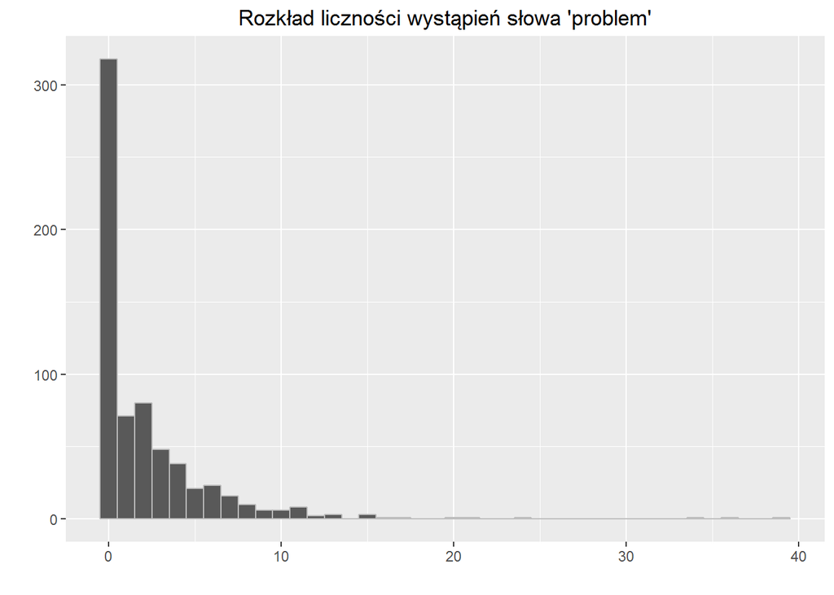

Jak widać, otrzymany rozkład nie jest rozkładem Poissona. Podobne wyniki otrzymaliśmy dla pozostałych słów, dlatego uznaliśmy, że to podejście jest niewłaściwe.

Postanowiliśmy więc uciec się do nieparametrycznej formy wyznaczenia rozkładu poprzez stworzenie dystrybuant empirycznych dla dziennej ilości wystąpień interesujących nas słów. Zostały one zbudowane na danych historycznych i zapisane do plików `.rda`, aby można było je wykorzystać w późniejszej analizie. Oto fragment kodu odpowiedzialny za budowanie dystrybuant:

```r
slowo_cdf <- function(slowo, godziny = 0:24, dni = 1:5){
  ilosc_work <- 661
  ilosc_weekend <- 265
  d %>% filter(podstawa == slowo, godzina %in% godziny,dzien %in% dni) %>%
    count(data) -> tmp
  tmp <- tmp$n
  tmp <- c(tmp, rep(0, times = ilosc_work - length(tmp) ))
  return(ecdf(tmp))
}

cdfy <- lapply(slowa, slowo_cdf, godziny = 0:24)

names(cdfy) <- slowa
```

Stworzona funkcja pozwala na dobranie odpowiedniego przedziału godzin i dni, aczkolwiek ograniczyliśmy się tylko do podziału na tydzień/weekend. Przy tworzeniu dystrybuant uwzględniliśmy także dni, w których dane słowa nie wystąpiły - inaczej zakładalibyśmy, że codziennie każde słowo pojawia się conajmniej raz.  
Testy tej metody oparte na danych historycznych pokazały, że jest ona użyteczna - wśród dni, dla których prawy ogon dystrybuanty przyjmuje wartość mniejszą niż $0.05$, zdecydowana większość zawierała posty klientów skarżących się na trudności techniczne z działaniem różnych usług bankowych.

### Narzędzie do wykrywania problemów

Pierwszą częścią narzędzia jest skrypt, który podlicza wystąpienia kluczowych słów w ciągu ostatnich 24 godzin przed jego wywołaniem, sprawdza odpowiednie prawdopodobieństwa za pomocą wcześniej wyestymowanych dystrybuant, a następnie w przypadku przekroczenia progu $0.05$ przez którąś z otrzymach wartości generuje raport dotyczący analizowanego przedziału czasowego.  
Niestety ze względu na to, że podczas trzeciej fazy wrócilismy do pierwotnego modelu pracy w grupach nie mieliśmy możliwości przetestowania algorytmu na danych pobieranych w czasie rzeczywistym, gdyż grupa odpowiedzialna za bazę danych zaniechała jej dalszego usprawniania. Dlatego ograniczyliśmy się do testów na danych historycznych.

```r
load("dane_ing_rozklad.rda")
load("dane_ing_kor.rda")
load("cdfy_tydzien.rda")
load("cdfy_weekend.rda")
load("final.rda")
load("rama.rda")
library(dplyr)
library(stringi)

# kodowanie danych w przypadku systemu Windows
if(.Platform$OS.type == "windows") {
  dane_ing_kor$body_korekta <- stri_encode(as.character(dane_ing_kor$body_korekta), from = "utf8", to = "cp1250")
  dane_ing_kor$body <- stri_encode(as.character(dane_ing_kor$body), from = "utf8", to = "cp1250")
  dane_ing_kor$user_name <- stri_encode(as.character(dane_ing_kor$user_name), from = "utf8", to = "cp1250")
  dane_ing_rozklad$podstawa <- stri_encode(as.character(dane_ing_rozklad$podstawa), from = "utf8", to = "cp1250")
}


now <-as.POSIXlt(strptime("2015-07-27 17:00:01", "%Y-%m-%d %H:%M:%S"))
weekday <- now$wday

### selekcja czasów

time_begin <- now - as.difftime(1, unit="days")

final %>% filter(as.POSIXct(data)<= now & as.POSIXct(data) >= time_begin) -> wydzwiek_wczoraj
dane_ing_kor %>% filter(as.POSIXct(created_at)<= now & as.POSIXct(created_at) >= time_begin) -> dane_wczoraj
dane_ing_rozklad %>% filter(as.POSIXct(data)<= now & as.POSIXct(data) >= time_begin) -> rozklady_wczoraj
rozklady_wczoraj %>% count(podstawa) %>% arrange(desc(n))-> licznosci_wczoraj

### sprawdzanie słów

slowa <- c("problem", "działać", "utrudnienie", "reklamacja", "awaria", "błąd")
slowa <- sort(slowa)

# dni tygodnia numerowane od 0
if(weekday %in% c(0,6)){
  cdfy <- cdfy_weekend
}else{
  cdfy <- cdfy_tydzien
}
pstwa <- rep(1,6)
for(i in 1:6){
  slowo <- slowa[i]
  wynik <- 1- cdfy[[slowo]](licznosci_wczoraj$n[licznosci_wczoraj$podstawa == slowo])
  if(length(wynik)>0) pstwa[i] <- wynik
}

dzien <- stri_sub(now, 1, 10)
nazwa_pliku <- stri_replace_all_fixed(as.character(now),pattern = c(":"), replacement = "_")

rmarkdown::render("raport_faza3.Rmd", encoding = "utf8", output_file = paste0("raport", nazwa_pliku, ".pdf"))
```

### Raport

Raport na wejściu ma podawane cztery ramki danych, z których korzysta:

- `dane_wczoraj` - tabela z postami z ostatnich 24 godzin,
- `rozklady_wczoraj` - tabela z rozkladami postów z ostatnich 24 godzin,
- `wydzwiek_wczoraj` - tabela z informacją o wydźwięku dla każdego postu,
- `licznosci_wczoraj` - tabela z licznościami słów z postów.

##### **Podstawowe statystyki**

Zawierają informację o ilości osób, która umieściła post oraz o liczbie wątków (wraz z medianą liczby odpowiedzi).

```r
post_n <- dane_wczoraj %>% nrow
thread_n <- dane_wczoraj %>% filter(is.na(parent_id)) %>% nrow
thread_ans_n <- dane_wczoraj %>%  filter(!is.na(parent_id)) %>% count(parent_id)
dane_wczoraj %>%
   filter(is.na(parent_id))%>%
   select(id) %>%
   left_join(., y = thread_ans_n, by=c("id"="parent_id")) ->thread_ans_count
thread_ans_count$n <- ifelse(is.na(thread_ans_count$n),0,thread_ans_count$n)
```

##### **Rozkład liczby słów w postach**

Zaprezentowanie za pomocą wykresu pudełkowego rozkładu liczby słów w postach.

```r
post_word <- dane_wczoraj %>% select(body) %>% unlist %>% stri_count_words
df_post_word <- data.frame(value=post_word, variable=dzien)

ggplot(df_post_word, aes(y=value, x=variable))+geom_boxplot(fill="paleturquoise2", width = 0.55)+
   stat_summary(fun.y=mean, geom="point", shape=19, size=2, col = "firebrick3")+
   labs(y="Liczba słów", x="",title="" ) +
   scale_x_discrete(labels="")+
   coord_flip()
```

##### **Najaktywniejsi użytkownicy**

Tabela prezentująca 10 (bądź mniej) użytkowników, którzy byli najbardziej aktywni pod względem liczby umieszczonych postów.

```r
user_n <- dane_wczoraj %>% count(user_name) %>% arrange(desc(n))
user_n[order(unlist(user_n[,2]),decreasing=T),] %>% head(10) %>% pander
```

##### **Rozkład aktywności**

Wykres słupkowy prezentujący rozkład aktywności z podziałem na godziny (aktywność rozumiemy jako liczbę umieszczonych postów).

```r
time_act <- dane_wczoraj %>% select(created_at) %>% t() %>% stri_sub(from=12,to=13) %>% as.numeric
time_act <- cbind(godz=time_act, licz=1) %>% as.data.frame
r <- time_act %>% count(godz)
licznosci <- numeric(24)
for(i in 1:nrow(r)){
   licznosci[r$godz[i]] <- r$n[i]
}

df_licznosci <- data.frame(licznosci=licznosci)
df_licznosci_melt <- melt(df_licznosci)

ggplot(df_licznosci_melt, aes(x=seq(0,23), y=value))+geom_bar(stat="identity",fill="paleturquoise2") +
   labs(y="Liczba postów", x="Godzina",title="" ) +
   scale_x_continuous(breaks = seq(0,23)) +
   scale_y_continuous(breaks = seq(0,max(licznosci),2))
```

##### **Wydźwięk postów**

Tabela informująca o ilości postów negatywnych, neutralnych oraz pozytywnych z ostatnich 24 godzin.

```r
wydzwiek_wczoraj %>% count(jakie) -> licznosci_wydziwiek
colnames(licznosci_wydziwiek)[1] <- "wydzwięk"
licznosci_wydziwiek %>% pander
```

##### **Tematyka postów oraz weryfikacja problemu**

Zaprezetowanie tabeli ze złowami, które pojawiały sie najczęściej.

```r
licznosci_wczoraj <- licznosci_wczoraj[stri_length(licznosci_wczoraj$podstawa)>3,]
licznosci_wczoraj %>% head(10) %>% pander
```

Do weryfikacji problemów wykorzystano dystrybuanty skonstruowane na dancyh historycznych. W raporcie zaprezentowano tabelę, która informuje nas o ilości wystąpięń wyodrębnionych słów, o wartości ogona dystrybuanty emiprycznej oraz zawiera informację czy dane słowo wykryło problem.

```r
problem <- left_join(as.data.frame(slowa), licznosci_wczoraj, by=c("slowa"="podstawa"))
problem$n <- ifelse(is.na(problem$n),0,problem$n)

pstwo <- numeric(length(slowa))
for(i in 1:length(slowa)){
   x <- problem[i,]
   f <- cdfy[[as.character(x[1])]]
   pstwo[i] <- 1-f(as.numeric(x[2]-1))
}
czy_problem <- pstwo<0.05
problem <- cbind(problem, pstwo, czy_problem)
pander(problem)
```

### Analiza wydźwięku

Rozwiązanie oparte o sprawdzanie częstotliwości występowania kilku ustalonych słów ma swoje wady - najważniejszą jest ta, że jeśli wystąpi problem inny niż te zawarte w danych historycznych, to nasz algorytm może go nie wykryć, ze względu na nowe słownictwo pojawiające się w postach. Dlatego postanowiliśmy użyć bardziej uniwersalnej metody - analizy wydźwięku postów. Plik `rama.rda` zawiera ramkę danych z podstawowymi statystykami dla każdego z postów, którą możemy dodać do głównej ramki poprzez połączenie po kolumnie `id`. Oto kilka przykładowych wierszy z tej ramki:

```
##      id                data ocena_sum    ocena_sr ocena_med ilosc_slow zer
## 1 13999 2013-10-17 17:40:01         2  0.14285714         0         14  12
## 2 14000 2013-10-16 17:34:49        -2 -0.08695652         0         23  21
## 3 14001 2013-10-16 17:38:54         0  0.00000000         0          5   5
## 4 14002 2013-10-16 17:38:54         0  0.00000000         0          2   2
## 5 14003 2013-10-16 17:43:24         0  0.00000000         0          1   1
## 6 14004 2013-10-16 17:44:26         0  0.00000000         0          7   7
```

Mając gotową ramkę z intymi informacjami, oceniliśmy działanie kilku metod klasyfikowania postów. Ostatecznie zdecydowaliśmy, że post uznajemy za negatywny, jeśli przynajmniej $10 \%$ słów w nim zawartych ma ocenę negatywną. Za pomocą tak skonstruowanej metody udało się wykryć dni, w których nastąpiły problemy techniczne (na przykład 23.01.2014).  
Ta metoda niestety również jest bardzo ograniczona. Tak jak w przypadku poprzedniego sposobu, jesteśmy ograniczeni przez wielkość słownika (aczkolwiek w tym przypadku słownik można bardzo łatwo rozszerzać o nowe słowa). Nawet jeśli w jakiś sposób ominiemy ten problem, to negatywny wydźwięk komentarza wcale nie musi świadczyć o wystąpieniu awarii - może po prostu być przejawem tego, że osoba (niekoniecznie klient) po prostu wyraża swoją opinię na jakiś temat związany z bankiem. Przykładowo, za pomocą tej metody udało nam się znaleźć dzień (21-12-2015), w którym bardzo dużo osób krytykowało bank ING za poglądy polityczne Marka Kondrata.